# Big Spenders

## Introduction

In this short piece, I will investigate the most obvious question - Who spent the most?

## Libraries

```r
library(dplyr)
library(readr)
library(ggplot2)
```

## Data Load

I am using data from The Independent Parlimentary Standards Authority, who [provide data](http://www.parliamentary-standards.org.uk/DataDownloads.aspx) for all expense claims made by MP’s, grouped by year.

This analysis is using the 2015 expense claims csv.

I’m able to set the type of some columns whilst reading in the data. Readr cannot individually set columns as factors though, so these are manually set following the load.

TODO - Why am I converting some categories to factor. (answer - Can’t load as factor using readr)

```r
#Read data to expenses 2015
expenses2015 <- read_csv("Data/DataDownload_2015.csv",
                         col_types = cols(
                                        Date = col_date(format = "%d/%m/%Y"),
                                        `Claim No.` = col_character(),
                                        `Reason If Not Paid` = col_character(),
                                        `Amount Not Paid` = col_double()
                                         )
)
# Convert some columns to factor
#To do - Convert this to an elegant apply function...
# List of columns to convert to factors - `MP's Name`, `MP's Constituency`, Category,`Expense Type`, From, To, Travel
expenses2015$`MP's Name` <- as.factor(expenses2015$`MP's Name`)
expenses2015$`MP's Constituency` <- as.factor(expenses2015$`MP's Constituency`)
expenses2015$Category <- as.factor(expenses2015$Category)
expenses2015$`Expense Type` <- as.factor(expenses2015$`Expense Type`)
expenses2015$`MP's Name` <- as.factor(expenses2015$`MP's Name`)
expenses2015$From <- as.factor(expenses2015$From)
expenses2015$To <- as.factor(expenses2015$To)
expenses2015$Travel <- as.factor(expenses2015$Travel)
expenses2015$Status <- as.factor(expenses2015$Status)
expenses2015$`Reason If Not Paid` <- as.factor(expenses2015$`Reason If Not Paid`)
```

### Analysis 1 - Largest Expense Claims by Category

TODO - Add £ formatting to table and graph. TODO - Neaten x-axis labels (remove and use legend?)

Using the `group_by` function from Hadley’s `dplyr` package, we can group all our expense claims by category. Analysis of these groupings, such as mean, min, max, count and more advanced ideas can be explored.

To begin with, we will look at the maximum value claimed by an MP in each category. We may also wish to explore the mean, or median expense claim. A jitter plot could also be a useful way to explore the patterns in the data.

```r
expense_by_category <- expenses2015 %>% group_by(Category)
summarise(expense_by_category,  `Largest Claim (Â£)` = max(`Amount Claimed`), `Mean Claim (Â£)` = mean(`Amount Claimed`), `Median Claim (Â£)` = median(`Amount Claimed`), `Count of Claims` = n())
```

| Category | Largest Claim (£) | Mean Claim (£) | Median Claim (£) | Count of Claims |
| --- | --- | --- | --- | --- |
| Accommodation | 15138.0 | 614.48892 | 300.000 | 11685 |
| Miscellaneous Expenses | 3954.6 | 444.26840 | 151.960 | 667 |
| Office Costs | 20097.0 | 194.56869 | 62.180 | 58921 |
| Staffing | 16810.0 | 259.90380 | 5.400 | 7241 |
| Start Up | 5986.8 | 310.72019 | 103.695 | 2484 |
| Travel | 5532.0 | 48.70326 | 21.150 | 93648 |
| Winding Up | 15085.0 | 248.67571 | 74.710 | 2743 |

Whilst interesting, this isn’t particularly insightful. Let’s try visualising the data.

Things to note

- `geom_jitter` is the same as `geom_point` but with an inbuilt jitter, adding a slight element of random noise. This helps to visualise the data, spreading it out a little whilst maintaining the overall features.
- You can see that we actually have some negative claims plotted. These represent “refunded expenses” by the MP.

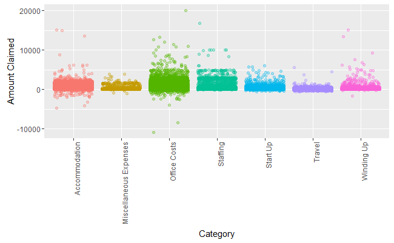

```r
ggplot(data = expenses2015, aes(y = `Amount Claimed`, x = Category, col = Category)) + geom_jitter(alpha = 0.3) + theme(axis.text.x = element_text(angle = 90, hjust = 1), legend.position = "none")
```

This is a much clearer way to display the data. We can immediately see the rough range, maximum claim and general trend of the data.